# Regresión simple y múltiple dataset FIFA

## 3.1. Matriz de Correlación.

Antes de generar la matriz de correlación, debemos quitar las variables categóricas dado que la función $cor$ no admite variables categóricas. Para ello, seleccionamos los nombres del dataframe que deseamos quitar, en este caso son “club”, “preferred_foot” y “team_position”.

Quitamos también la variable “…1” Ya que no aporta información valiosa para el análisis.

```r
names(caso)
```

```
##  [1] "...1"               "club"               "preferred_foot"
##  [4] "team_position"      "age"                "height_cm"
##  [7] "weight_kg"          "overall"            "potential"
## [10] "value_eur"          "wage_eur"           "release_clause_eur"
## [13] "shooting"           "passing"            "dribbling"
## [16] "defending"          "physic"             "pace"
```

Llamamos **caso2** al dataframe sin las variables categóricas-.

```r
borrar <- c("club", "preferred_foot", "team_position", "...1")
caso2 <- caso[, !(names(caso) %in% borrar)]

head(caso2, n=5)
```

```
## # A tibble: 5 × 14
##     age height…¹ weigh…² overall poten…³ value…⁴ wage_…⁵ relea…⁶ shoot…⁷ passing
##   <dbl>    <dbl>   <dbl>   <dbl>   <dbl>   <dbl>   <dbl>   <dbl>   <dbl>   <dbl>
## 1    19      182      75      59      75  325000    2000  723000      60      56
## 2    21      180      75      56      63  130000    1000  189000      43      51
## 3    21      193      77      69      76 1500000    5000 2500000      64      61
## 4    19      175      72      61      78  500000    7000 1100000      41      57
## 5    23      179      71      58      64  150000    1000  255000      28      33
## # … with 4 more variables: dribbling <dbl>, defending <dbl>, physic <dbl>,
## #   pace <dbl>, and abbreviated variable names ¹height_cm, ²weight_kg,
## #   ³potential, ⁴value_eur, ⁵wage_eur, ⁶release_clause_eur, ⁷shooting
```

- **Matriz de Correlación:**

```r
round(cor(caso2),2)
```

```
##                      age height_cm weight_kg overall potential value_eur
## age                 1.00      0.04      0.19    0.59     -0.14      0.21
## height_cm           0.04      1.00      0.76    0.08      0.05      0.01
## weight_kg           0.19      0.76      1.00    0.25      0.13      0.16
## overall             0.59      0.08      0.25    1.00      0.61      0.72
## potential          -0.14      0.05      0.13    0.61      1.00      0.63
## value_eur           0.21      0.01      0.16    0.72      0.63      1.00
## wage_eur            0.28      0.04      0.19    0.65      0.52      0.81
## release_clause_eur  0.18     -0.01      0.13    0.69      0.62      0.99
## shooting            0.36     -0.15     -0.04    0.50      0.24      0.35
## passing             0.46     -0.27     -0.16    0.67      0.42      0.47
## dribbling           0.27     -0.33     -0.24    0.60      0.42      0.47
## defending           0.19      0.23      0.25    0.25      0.19      0.13
## physic              0.38      0.51      0.62    0.49      0.19      0.31
## pace               -0.17     -0.35     -0.31    0.20      0.25      0.33
##                    wage_eur release_clause_eur shooting passing dribbling
## age                    0.28               0.18     0.36    0.46      0.27
## height_cm              0.04              -0.01    -0.15   -0.27     -0.33
## weight_kg              0.19               0.13    -0.04   -0.16     -0.24
## overall                0.65               0.69     0.50    0.67      0.60
## potential              0.52               0.62     0.24    0.42      0.42
## value_eur              0.81               0.99     0.35    0.47      0.47
## wage_eur               1.00               0.78     0.30    0.43      0.37
## release_clause_eur     0.78               1.00     0.34    0.46      0.47
## shooting               0.30               0.34     1.00    0.62      0.79
## passing                0.43               0.46     0.62    1.00      0.80
## dribbling              0.37               0.47     0.79    0.80      1.00
## defending              0.23               0.12    -0.49    0.10     -0.26
## physic                 0.34               0.28     0.03    0.14     -0.01
## pace                   0.15               0.35     0.41    0.28      0.59
##                    defending physic  pace
## age                     0.19   0.38 -0.17
## height_cm               0.23   0.51 -0.35
## weight_kg               0.25   0.62 -0.31
## overall                 0.25   0.49  0.20
## potential               0.19   0.19  0.25
## value_eur               0.13   0.31  0.33
## wage_eur                0.23   0.34  0.15
## release_clause_eur      0.12   0.28  0.35
## shooting               -0.49   0.03  0.41
## passing                 0.10   0.14  0.28
## dribbling              -0.26  -0.01  0.59
## defending               1.00   0.53 -0.38
## physic                  0.53   1.00 -0.17
## pace                   -0.38  -0.17  1.00
```

- Observamos que la variable **value_eur**, tiene una mayor relación de tipo lineal con las variables *overall*, *potential*, *wage_eur* y *release_clause_eur*.
- Las variables *wage_eur* y *release_clause_eur* tiene una relación lineal mayor que las otras variables, esto sugiere que una de las dos no debería ir en el modelo.

**Observación:** Omitimos las gráficas ggpairs de GGally y multi.hist de psych ya que al haber 14 variables numéricas, los gráficos generados no se ven claramente.

## 3.2. Modelo.

- Selección de los mejores predictores

### 3.2.1. Modelo sin variables explicativas.

Para ello podemos usar la expresión formula = *variable ~ 1*

```r
modsinvariables <- lm(formula=caso2$value_eur~1, caso2)
summary(modsinvariables)
```

```
##
## Call:
## lm(formula = caso2$value_eur ~ 1, data = caso2)
##
## Residuals:
##      Min       1Q   Median       3Q      Max
## -2047400 -1722400 -1384900   -97400 21902600
##
## Coefficients:
##             Estimate Std. Error t value Pr(>|t|)
## (Intercept)  2097400     280525   7.477 6.05e-12 ***
## ---
## Signif. codes:  0 '***' 0.001 '**' 0.01 '*' 0.05 '.' 0.1 ' ' 1
##
## Residual standard error: 3436000 on 149 degrees of freedom
```

### 3.2.2. Modelo con todas las variables explicativas.

```r
modcompleto <- lm(formula=caso2$value_eur~., caso2)
summary(modcompleto)
```

```
##
## Call:
## lm(formula = caso2$value_eur ~ ., data = caso2)
##
## Residuals:
##     Min      1Q  Median      3Q     Max
## -956704 -147217  -19894  112172 1857161
##
## Coefficients:
##                      Estimate Std. Error t value Pr(>|t|)
## (Intercept)        -1.756e+06  1.454e+06  -1.208  0.22921
## age                -2.274e+04  1.639e+04  -1.387  0.16762
## height_cm          -2.572e+03  8.391e+03  -0.307  0.75965
## weight_kg           1.372e+04  9.844e+03   1.393  0.16579
## overall             4.514e+04  1.478e+04   3.053  0.00272 **
## potential          -1.274e+04  1.281e+04  -0.994  0.32183
## wage_eur            1.373e+01  3.248e+00   4.228  4.3e-05 ***
## release_clause_eur  4.548e-01  9.409e-03  48.337  < 2e-16 ***
## shooting            4.269e+03  5.739e+03   0.744  0.45818
## passing             1.091e+04  6.488e+03   1.681  0.09509 .
## dribbling          -1.963e+04  8.337e+03  -2.354  0.01999 *
## defending          -1.397e+03  3.723e+03  -0.375  0.70802
## physic             -1.304e+03  5.322e+03  -0.245  0.80682
## pace                5.761e+03  4.514e+03   1.276  0.20407
## ---
## Signif. codes:  0 '***' 0.001 '**' 0.01 '*' 0.05 '.' 0.1 ' ' 1
##
## Residual standard error: 393000 on 136 degrees of freedom
## Multiple R-squared:  0.9881, Adjusted R-squared:  0.9869
## F-statistic: 865.5 on 13 and 136 DF,  p-value: < 2.2e-16
```

Observamos que de las variables explicativas, hay algunas que tienen un $p-value > 0.05$ en la prueba de hipótesis $H_0 : \beta_i = 0$ y serían candidatas a no estar en el modelo porque no son significativas, tales como: age, height_cm, weight_kg, potential, shooting, passing, defending, physic, pace.

### 3.2.3. Dirección forward

```r
modforward <- step(modsinvariables,
                   scope = list(lower=modsinvariables, upper = modcompleto),
                   direction = "forward")
```

```
## Start:  AIC=4515.92
## caso2$value_eur ~ 1
##
##                      Df  Sum of Sq        RSS    AIC
## + release_clause_eur  1 1.7284e+15 3.0390e+13 3909.2
## + wage_eur            1 1.1508e+15 6.0806e+14 4358.6
## + overall             1 9.1836e+14 8.4046e+14 4407.2
## + potential           1 6.9520e+14 1.0636e+15 4442.5
## + passing             1 3.9108e+14 1.3677e+15 4480.2
## + dribbling           1 3.8789e+14 1.3709e+15 4480.5
## + shooting            1 2.1795e+14 1.5409e+15 4498.1
## + pace                1 1.9526e+14 1.5636e+15 4500.3
## + physic              1 1.7187e+14 1.5869e+15 4502.5
## + age                 1 7.7608e+13 1.6812e+15 4511.1
## + weight_kg           1 4.5754e+13 1.7131e+15 4514.0
## + defending           1 3.1904e+13 1.7269e+15 4515.2
## <none>                             1.7588e+15 4515.9
## + height_cm           1 3.9004e+11 1.7584e+15 4517.9
##
## Step:  AIC=3909.18
## caso2$value_eur ~ release_clause_eur
##
##             Df  Sum of Sq        RSS    AIC
## + wage_eur   1 4.8018e+12 2.5589e+13 3885.4
## + overall    1 4.4925e+12 2.5898e+13 3887.2
## + weight_kg  1 1.9486e+12 2.8442e+13 3901.2
## + physic     1 1.8229e+12 2.8567e+13 3901.9
## + age        1 1.6658e+12 2.8725e+13 3902.7
## + passing    1 9.1659e+11 2.9474e+13 3906.6
## + height_cm  1 7.2133e+11 2.9669e+13 3907.6
## + shooting   1 6.0017e+11 2.9790e+13 3908.2
## + defending  1 5.0428e+11 2.9886e+13 3908.7
## <none>                    3.0390e+13 3909.2
## + potential  1 3.4925e+11 3.0041e+13 3909.4
## + pace       1 1.7174e+11 3.0219e+13 3910.3
## + dribbling  1 4.9093e+10 3.0341e+13 3910.9
##
## Step:  AIC=3885.38
## caso2$value_eur ~ release_clause_eur + wage_eur
##
```

[output cut: 29 more lines]

```
##
## Step:  AIC=3868.39
## caso2$value_eur ~ release_clause_eur + wage_eur + overall + weight_kg
##
##             Df  Sum of Sq        RSS    AIC
## <none>                    2.2247e+13 3868.4
## + pace       1 1.3729e+11 2.2109e+13 3869.5
## + age        1 9.0717e+10 2.2156e+13 3869.8
## + defending  1 5.5950e+10 2.2191e+13 3870.0
## + dribbling  1 4.5152e+10 2.2201e+13 3870.1
## + physic     1 2.8591e+10 2.2218e+13 3870.2
## + shooting   1 2.1671e+10 2.2225e+13 3870.2
## + height_cm  1 1.3940e+10 2.2233e+13 3870.3
## + passing    1 1.3721e+10 2.2233e+13 3870.3
## + potential  1 2.2177e+09 2.2244e+13 3870.4
```

```r
summary(modforward)
```

```
##
## Call:
## lm(formula = caso2$value_eur ~ release_clause_eur + wage_eur +
##     overall + weight_kg, data = caso2)
##
## Residuals:
##      Min       1Q   Median       3Q      Max
## -1103633  -150080    -8719    88331  1832539
##
## Coefficients:
##                      Estimate Std. Error t value Pr(>|t|)
## (Intercept)        -2.379e+06  5.440e+05  -4.373 2.33e-05 ***
## release_clause_eur  4.590e-01  8.351e-03  54.962  < 2e-16 ***
## wage_eur            1.321e+01  3.115e+00   4.241 3.95e-05 ***
## overall             2.575e+04  6.890e+03   3.738 0.000266 ***
## weight_kg           1.136e+04  5.688e+03   1.997 0.047660 *
## ---
## Signif. codes:  0 '***' 0.001 '**' 0.01 '*' 0.05 '.' 0.1 ' ' 1
##
## Residual standard error: 391700 on 145 degrees of freedom
## Multiple R-squared:  0.9874, Adjusted R-squared:  0.987
## F-statistic:  2830 on 4 and 145 DF,  p-value: < 2.2e-16
```

```r
summary(lm(formula = caso2$value_eur ~ release_clause_eur + wage_eur + overall + weight_kg, data = caso2))
```

```
##
## Call:
## lm(formula = caso2$value_eur ~ release_clause_eur + wage_eur +
##     overall + weight_kg, data = caso2)
##
## Residuals:
##      Min       1Q   Median       3Q      Max
## -1103633  -150080    -8719    88331  1832539
##
## Coefficients:
##                      Estimate Std. Error t value Pr(>|t|)
## (Intercept)        -2.379e+06  5.440e+05  -4.373 2.33e-05 ***
## release_clause_eur  4.590e-01  8.351e-03  54.962  < 2e-16 ***
## wage_eur            1.321e+01  3.115e+00   4.241 3.95e-05 ***
## overall             2.575e+04  6.890e+03   3.738 0.000266 ***
## weight_kg           1.136e+04  5.688e+03   1.997 0.047660 *
## ---
## Signif. codes:  0 '***' 0.001 '**' 0.01 '*' 0.05 '.' 0.1 ' ' 1
##
## Residual standard error: 391700 on 145 degrees of freedom
## Multiple R-squared:  0.9874, Adjusted R-squared:  0.987
## F-statistic:  2830 on 4 and 145 DF,  p-value: < 2.2e-16
```

### 3.2.4. Dirección backward

```r
modbackward <- step(modcompleto,
                   scope = list(lower=modsinvariables,
                                upper = modcompleto),
                   direction = "backward")
```

```
## Start:  AIC=3877.77
## caso2$value_eur ~ age + height_cm + weight_kg + overall + potential +
##     wage_eur + release_clause_eur + shooting + passing + dribbling +
##     defending + physic + pace
##
##                      Df  Sum of Sq        RSS    AIC
## - physic              1 9.2719e+09 2.1015e+13 3875.8
## - height_cm           1 1.4515e+10 2.1020e+13 3875.9
## - defending           1 2.1756e+10 2.1027e+13 3875.9
## - shooting            1 8.5487e+10 2.1091e+13 3876.4
## - potential           1 1.5271e+11 2.1158e+13 3876.9
## - pace                1 2.5155e+11 2.1257e+13 3877.6
## <none>                             2.1005e+13 3877.8
## - age                 1 2.9726e+11 2.1303e+13 3877.9
## - weight_kg           1 2.9986e+11 2.1305e+13 3877.9
## - passing             1 4.3635e+11 2.1442e+13 3878.9
## - dribbling           1 8.5599e+11 2.1861e+13 3881.8
## - overall             1 1.4397e+12 2.2445e+13 3885.7
## - wage_eur            1 2.7607e+12 2.3766e+13 3894.3
## - release_clause_eur  1 3.6087e+14 3.8187e+14 4310.8
##
## Step:  AIC=3875.84
## caso2$value_eur ~ age + height_cm + weight_kg + overall + potential +
##     wage_eur + release_clause_eur + shooting + passing + dribbling +
##     defending + pace
##
##                      Df  Sum of Sq        RSS    AIC
## - height_cm           1 1.8458e+10 2.1033e+13 3874.0
## - defending           1 4.8193e+10 2.1063e+13 3874.2
## - shooting            1 7.7348e+10 2.1092e+13 3874.4
## - potential           1 1.4464e+11 2.1159e+13 3874.9
## - pace                1 2.4383e+11 2.1259e+13 3875.6
## <none>                             2.1015e+13 3875.8
## - age                 1 2.9564e+11 2.1310e+13 3875.9
## - weight_kg           1 2.9874e+11 2.1313e+13 3876.0
## - passing             1 4.5569e+11 2.1470e+13 3877.1
## - dribbling           1 8.5367e+11 2.1868e+13 3879.8
## - overall             1 1.4409e+12 2.2456e+13 3883.8
## - wage_eur            1 2.7731e+12 2.3788e+13 3892.4
## - release_clause_eur  1 3.6152e+14 3.8253e+14 4309.1
```

[output cut: 101 more lines]

```
## <none>                             2.2109e+13 3869.5
## - weight_kg           1 7.4563e+11 2.2855e+13 3872.4
## - overall             1 2.0692e+12 2.4179e+13 3880.9
## - wage_eur            1 2.8910e+12 2.5000e+13 3885.9
## - release_clause_eur  1 4.0644e+14 4.2854e+14 4312.1
##
## Step:  AIC=3868.39
## caso2$value_eur ~ weight_kg + overall + wage_eur + release_clause_eur
##
##                      Df  Sum of Sq        RSS    AIC
## <none>                             2.2247e+13 3868.4
## - weight_kg           1 6.1207e+11 2.2859e+13 3870.5
## - overall             1 2.1436e+12 2.4390e+13 3880.2
## - wage_eur            1 2.7593e+12 2.5006e+13 3883.9
## - release_clause_eur  1 4.6346e+14 4.8571e+14 4328.9
```

```r
summary(modbackward)
```

```
##
## Call:
## lm(formula = caso2$value_eur ~ weight_kg + overall + wage_eur +
##     release_clause_eur, data = caso2)
##
## Residuals:
##      Min       1Q   Median       3Q      Max
## -1103633  -150080    -8719    88331  1832539
##
## Coefficients:
##                      Estimate Std. Error t value Pr(>|t|)
## (Intercept)        -2.379e+06  5.440e+05  -4.373 2.33e-05 ***
## weight_kg           1.136e+04  5.688e+03   1.997 0.047660 *
## overall             2.575e+04  6.890e+03   3.738 0.000266 ***
## wage_eur            1.321e+01  3.115e+00   4.241 3.95e-05 ***
## release_clause_eur  4.590e-01  8.351e-03  54.962  < 2e-16 ***
## ---
## Signif. codes:  0 '***' 0.001 '**' 0.01 '*' 0.05 '.' 0.1 ' ' 1
##
## Residual standard error: 391700 on 145 degrees of freedom
## Multiple R-squared:  0.9874, Adjusted R-squared:  0.987
## F-statistic:  2830 on 4 and 145 DF,  p-value: < 2.2e-16
```

### 3.2.5. Dirección Stepwise-Mixta.

```r
modmixto <- step(modsinvariables,
                   scope = list(lower=modsinvariables,
                                upper = modcompleto),
                   direction = "both")
```

```
## Start:  AIC=4515.92
## caso2$value_eur ~ 1
##
##                      Df  Sum of Sq        RSS    AIC
## + release_clause_eur  1 1.7284e+15 3.0390e+13 3909.2
## + wage_eur            1 1.1508e+15 6.0806e+14 4358.6
## + overall             1 9.1836e+14 8.4046e+14 4407.2
## + potential           1 6.9520e+14 1.0636e+15 4442.5
## + passing             1 3.9108e+14 1.3677e+15 4480.2
## + dribbling           1 3.8789e+14 1.3709e+15 4480.5
## + shooting            1 2.1795e+14 1.5409e+15 4498.1
## + pace                1 1.9526e+14 1.5636e+15 4500.3
## + physic              1 1.7187e+14 1.5869e+15 4502.5
## + age                 1 7.7608e+13 1.6812e+15 4511.1
## + weight_kg           1 4.5754e+13 1.7131e+15 4514.0
## + defending           1 3.1904e+13 1.7269e+15 4515.2
## <none>                             1.7588e+15 4515.9
## + height_cm           1 3.9004e+11 1.7584e+15 4517.9
##
## Step:  AIC=3909.18
## caso2$value_eur ~ release_clause_eur
##
##                      Df  Sum of Sq        RSS    AIC
## + wage_eur            1 4.8018e+12 2.5589e+13 3885.4
## + overall             1 4.4925e+12 2.5898e+13 3887.2
## + weight_kg           1 1.9486e+12 2.8442e+13 3901.2
## + physic              1 1.8229e+12 2.8567e+13 3901.9
## + age                 1 1.6658e+12 2.8725e+13 3902.7
## + passing             1 9.1659e+11 2.9474e+13 3906.6
## + height_cm           1 7.2133e+11 2.9669e+13 3907.6
## + shooting            1 6.0017e+11 2.9790e+13 3908.2
## + defending           1 5.0428e+11 2.9886e+13 3908.7
## <none>                             3.0390e+13 3909.2
## + potential           1 3.4925e+11 3.0041e+13 3909.4
## + pace                1 1.7174e+11 3.0219e+13 3910.3
## + dribbling           1 4.9093e+10 3.0341e+13 3910.9
## - release_clause_eur  1 1.7284e+15 1.7588e+15 4515.9
##
## Step:  AIC=3885.38
## caso2$value_eur ~ release_clause_eur + wage_eur
```

[output cut: 39 more lines]

```
##                      Df  Sum of Sq        RSS    AIC
## <none>                             2.2247e+13 3868.4
## + pace                1 1.3729e+11 2.2109e+13 3869.5
## + age                 1 9.0717e+10 2.2156e+13 3869.8
## + defending           1 5.5950e+10 2.2191e+13 3870.0
## + dribbling           1 4.5152e+10 2.2201e+13 3870.1
## + physic              1 2.8591e+10 2.2218e+13 3870.2
## + shooting            1 2.1671e+10 2.2225e+13 3870.2
## + height_cm           1 1.3940e+10 2.2233e+13 3870.3
## + passing             1 1.3721e+10 2.2233e+13 3870.3
## + potential           1 2.2177e+09 2.2244e+13 3870.4
## - weight_kg           1 6.1207e+11 2.2859e+13 3870.5
## - overall             1 2.1436e+12 2.4390e+13 3880.2
## - wage_eur            1 2.7593e+12 2.5006e+13 3883.9
## - release_clause_eur  1 4.6346e+14 4.8571e+14 4328.9
```

```r
summary(modmixto)
```

```
##
## Call:
## lm(formula = caso2$value_eur ~ release_clause_eur + wage_eur +
##     overall + weight_kg, data = caso2)
##
## Residuals:
##      Min       1Q   Median       3Q      Max
## -1103633  -150080    -8719    88331  1832539
##
## Coefficients:
##                      Estimate Std. Error t value Pr(>|t|)
## (Intercept)        -2.379e+06  5.440e+05  -4.373 2.33e-05 ***
## release_clause_eur  4.590e-01  8.351e-03  54.962  < 2e-16 ***
## wage_eur            1.321e+01  3.115e+00   4.241 3.95e-05 ***
## overall             2.575e+04  6.890e+03   3.738 0.000266 ***
## weight_kg           1.136e+04  5.688e+03   1.997 0.047660 *
## ---
## Signif. codes:  0 '***' 0.001 '**' 0.01 '*' 0.05 '.' 0.1 ' ' 1
##
## Residual standard error: 391700 on 145 degrees of freedom
## Multiple R-squared:  0.9874, Adjusted R-squared:  0.987
## F-statistic:  2830 on 4 and 145 DF,  p-value: < 2.2e-16
```

Otra forma de encontrar el modelo con la instrucción step es:

```r
step(object = lm(caso2$value_eur~ . , caso2),
     direction = "both",
     trace = 1) # "mejor modelo"
```

```
## Start:  AIC=3877.77
## caso2$value_eur ~ age + height_cm + weight_kg + overall + potential +
##     wage_eur + release_clause_eur + shooting + passing + dribbling +
##     defending + physic + pace
##
##                      Df  Sum of Sq        RSS    AIC
## - physic              1 9.2719e+09 2.1015e+13 3875.8
## - height_cm           1 1.4515e+10 2.1020e+13 3875.9
## - defending           1 2.1756e+10 2.1027e+13 3875.9
## - shooting            1 8.5487e+10 2.1091e+13 3876.4
## - potential           1 1.5271e+11 2.1158e+13 3876.9
## - pace                1 2.5155e+11 2.1257e+13 3877.6
## <none>                             2.1005e+13 3877.8
## - age                 1 2.9726e+11 2.1303e+13 3877.9
## - weight_kg           1 2.9986e+11 2.1305e+13 3877.9
## - passing             1 4.3635e+11 2.1442e+13 3878.9
## - dribbling           1 8.5599e+11 2.1861e+13 3881.8
## - overall             1 1.4397e+12 2.2445e+13 3885.7
## - wage_eur            1 2.7607e+12 2.3766e+13 3894.3
## - release_clause_eur  1 3.6087e+14 3.8187e+14 4310.8
##
## Step:  AIC=3875.84
## caso2$value_eur ~ age + height_cm + weight_kg + overall + potential +
##     wage_eur + release_clause_eur + shooting + passing + dribbling +
##     defending + pace
##
##                      Df  Sum of Sq        RSS    AIC
## - height_cm           1 1.8458e+10 2.1033e+13 3874.0
## - defending           1 4.8193e+10 2.1063e+13 3874.2
## - shooting            1 7.7348e+10 2.1092e+13 3874.4
## - potential           1 1.4464e+11 2.1159e+13 3874.9
## - pace                1 2.4383e+11 2.1259e+13 3875.6
## <none>                             2.1015e+13 3875.8
## - age                 1 2.9564e+11 2.1310e+13 3875.9
## - weight_kg           1 2.9874e+11 2.1313e+13 3876.0
## - passing             1 4.5569e+11 2.1470e+13 3877.1
## + physic              1 9.2719e+09 2.1005e+13 3877.8
## - dribbling           1 8.5367e+11 2.1868e+13 3879.8
## - overall             1 1.4409e+12 2.2456e+13 3883.8
## - wage_eur            1 2.7731e+12 2.3788e+13 3892.4
```

[output cut: 146 more lines]

```
##                      Df  Sum of Sq        RSS    AIC
## <none>                             2.2247e+13 3868.4
## + pace                1 1.3729e+11 2.2109e+13 3869.5
## + age                 1 9.0717e+10 2.2156e+13 3869.8
## + defending           1 5.5950e+10 2.2191e+13 3870.0
## + dribbling           1 4.5152e+10 2.2201e+13 3870.1
## + physic              1 2.8591e+10 2.2218e+13 3870.2
## + shooting            1 2.1671e+10 2.2225e+13 3870.2
## + height_cm           1 1.3940e+10 2.2233e+13 3870.3
## + passing             1 1.3721e+10 2.2233e+13 3870.3
## + potential           1 2.2177e+09 2.2244e+13 3870.4
## - weight_kg           1 6.1207e+11 2.2859e+13 3870.5
## - overall             1 2.1436e+12 2.4390e+13 3880.2
## - wage_eur            1 2.7593e+12 2.5006e+13 3883.9
## - release_clause_eur  1 4.6346e+14 4.8571e+14 4328.9
```

```
##
## Call:
## lm(formula = caso2$value_eur ~ weight_kg + overall + wage_eur +
##     release_clause_eur, data = caso2)
##
## Coefficients:
##        (Intercept)           weight_kg             overall            wage_eur
##         -2.379e+06           1.136e+04           2.575e+04           1.321e+01
## release_clause_eur
##          4.590e-01
```

De ahí podemos observar que el mejor modelo por este método es:

```r
modeloBest <- lm(formula = caso2$value_eur ~ weight_kg + overall + wage_eur +
    release_clause_eur, data = caso2)

summary(modeloBest)
```

```
##
## Call:
## lm(formula = caso2$value_eur ~ weight_kg + overall + wage_eur +
##     release_clause_eur, data = caso2)
##
## Residuals:
##      Min       1Q   Median       3Q      Max
## -1103633  -150080    -8719    88331  1832539
##
## Coefficients:
##                      Estimate Std. Error t value Pr(>|t|)
## (Intercept)        -2.379e+06  5.440e+05  -4.373 2.33e-05 ***
## weight_kg           1.136e+04  5.688e+03   1.997 0.047660 *
## overall             2.575e+04  6.890e+03   3.738 0.000266 ***
## wage_eur            1.321e+01  3.115e+00   4.241 3.95e-05 ***
## release_clause_eur  4.590e-01  8.351e-03  54.962  < 2e-16 ***
## ---
## Signif. codes:  0 '***' 0.001 '**' 0.01 '*' 0.05 '.' 0.1 ' ' 1
##
## Residual standard error: 391700 on 145 degrees of freedom
## Multiple R-squared:  0.9874, Adjusted R-squared:  0.987
## F-statistic:  2830 on 4 and 145 DF,  p-value: < 2.2e-16
```

Veamos los intervalos de confianza de cada uno de los parámetros.

```r
confint(lm(formula = caso2$value_eur ~ weight_kg + overall + wage_eur +
    release_clause_eur, data = caso2))
```

```
##                            2.5 %        97.5 %
## (Intercept)        -3.453927e+06 -1.303628e+06
## weight_kg           1.187436e+02  2.260152e+04
## overall             1.213630e+04  3.937206e+04
## wage_eur            7.054218e+00  1.936875e+01
## release_clause_eur  4.424817e-01  4.754928e-01
```

## 3.3. Validación de las Hipótesis del modelo.

Verificación de las hipótesis del modelo de regresión lineal múltiple.

### 3.3.1 Relación lineal entre los predictores y la variable de respuesta.

Como en el modelo lineal simple, esto se observa de los diagramas de dispersión de las variables.

```r
names(caso2)
```

```
##  [1] "age"                "height_cm"          "weight_kg"
##  [4] "overall"            "potential"          "value_eur"
##  [7] "wage_eur"           "release_clause_eur" "shooting"
## [10] "passing"            "dribbling"          "defending"
## [13] "physic"             "pace"
```

```r
round(cor(caso2[,c(3, 4, 7, 8)]),4)
```

```
##                    weight_kg overall wage_eur release_clause_eur
## weight_kg             1.0000  0.2501   0.1892             0.1294
## overall               0.2501  1.0000   0.6472             0.6921
## wage_eur              0.1892  0.6472   1.0000             0.7832
## release_clause_eur    0.1294  0.6921   0.7832             1.0000
```

### 3.3.2. Gráfica de predictor vs residual, de cada uno de los predictores.

Recordemos, que debe haber una distribución alrededor de cero aleatoriamente.

Usando ggplot y la instrucción librería gridExtra para hacer varios gráficos en un solo panel.

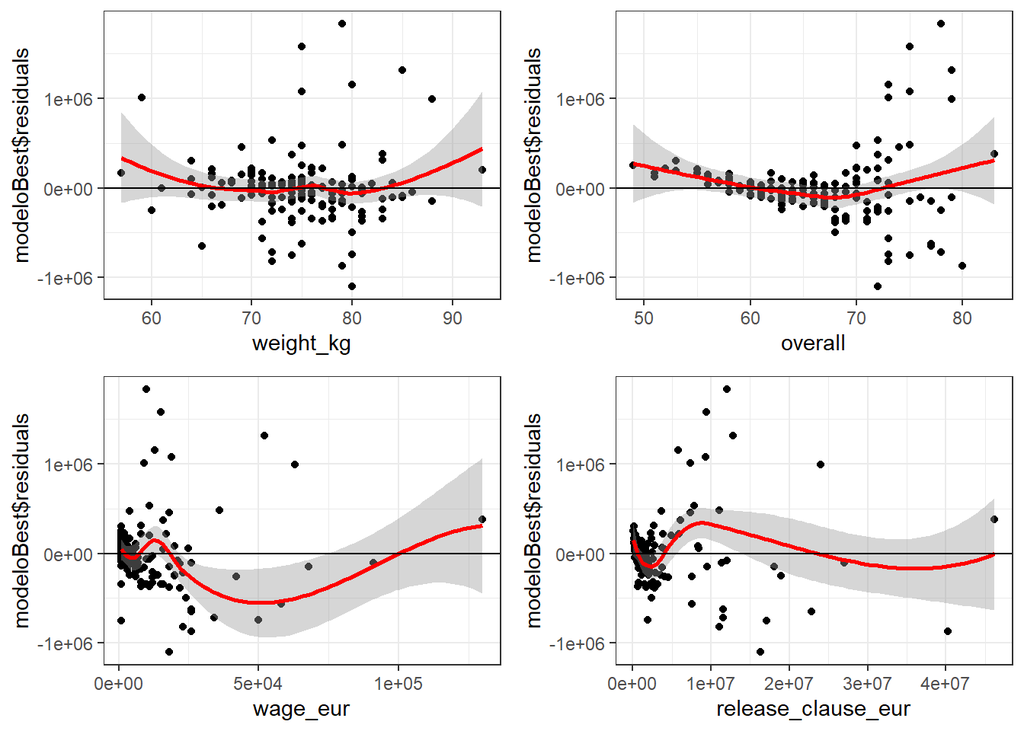

```r
grafica1 <- ggplot(data = caso2, aes(weight_kg,              modeloBest$residuals)) +
    geom_point() +
    geom_smooth(formula = y~x, color = "red", method = "loess") +
    geom_hline(yintercept = 0) +
    theme_bw()

grafica2 <- ggplot(data = caso2, aes(overall, modeloBest$residuals))+
            geom_point() +
            geom_smooth(formula = y~x, color = "red", method = "loess") +
            geom_hline(yintercept = 0) +
            theme_bw()

grafica3 <- ggplot(data = caso2, aes(wage_eur, modeloBest$residuals))+
            geom_point() +
            geom_smooth(formula = y~x, color = "red", method = "loess") +
            geom_hline(yintercept = 0) +
            theme_bw()

grafica4 <- ggplot(data = caso2, aes(release_clause_eur, modeloBest$residuals))+
            geom_point() +
            geom_smooth(formula = y~x, color = "red", method = "loess") +
            geom_hline(yintercept = 0) +
            theme_bw()


grid.arrange(grafica1, grafica2, grafica3, grafica4)
```

### 3.3.3. Linealidad de los residuos.

Calculamos la media de los residuos.

```r
mean(modeloBest$residuals)
```

```
## [1] -4.550505e-12
```

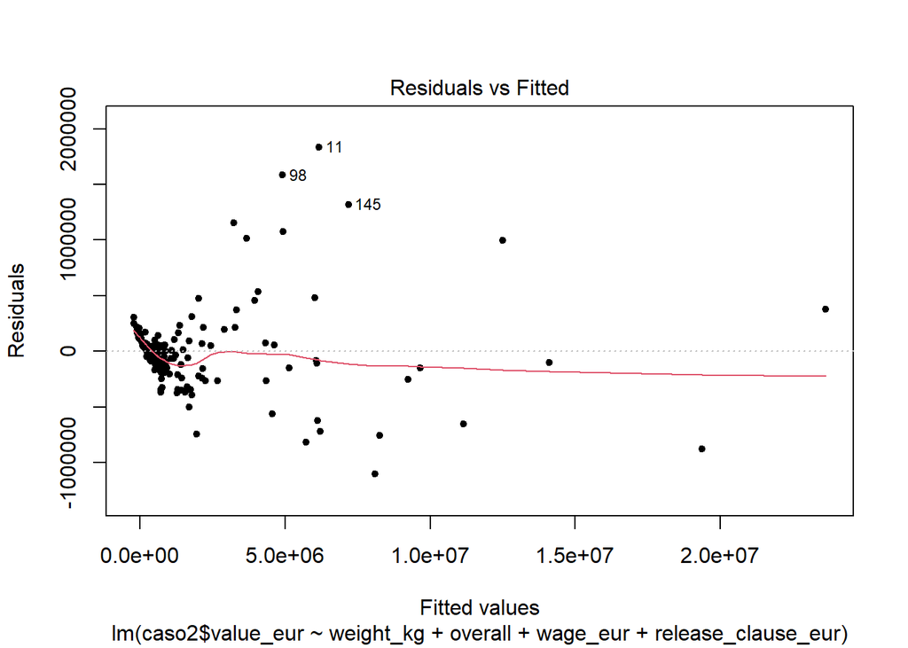

```r
plot(modeloBest,1, pch=20)
```

Observamos que los datos están dispersos y no hay patrón, además de que la recta roja se comporta bastante bien (tiende a ser horizontal).

### 3.3.4. Normalidad.

Examinemos el qqPlot, la gráfica cuantil_muestra-cuantil_teórico

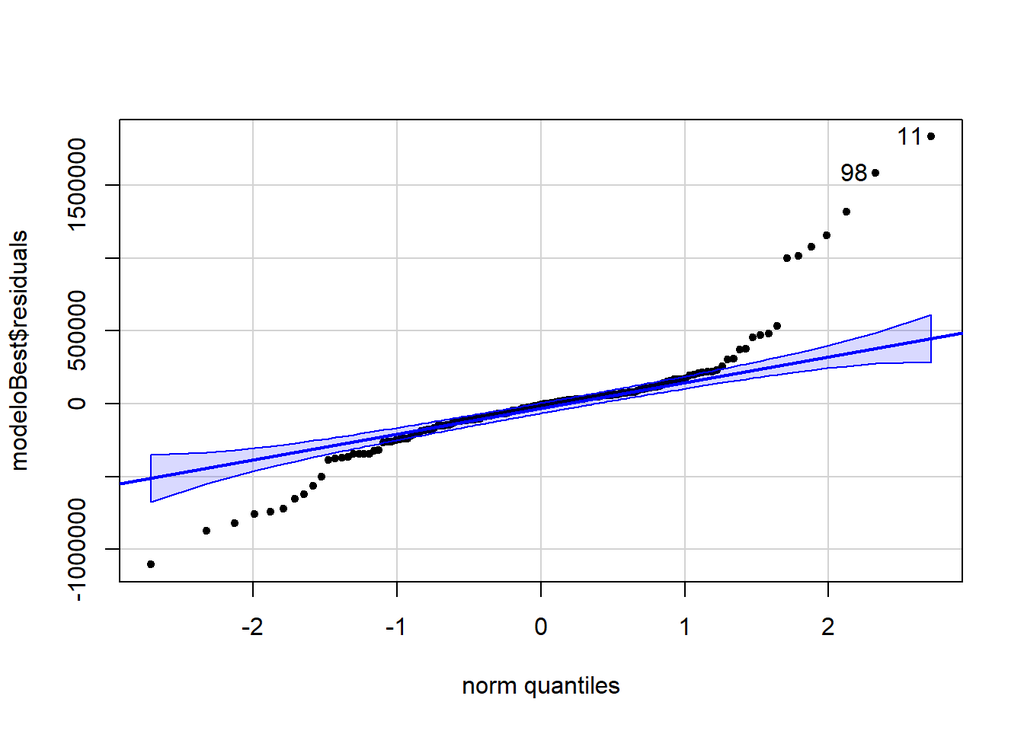

```
## [1] 11 98
```

```r
qqPlot(modeloBest$residuals,  pch=20)
```

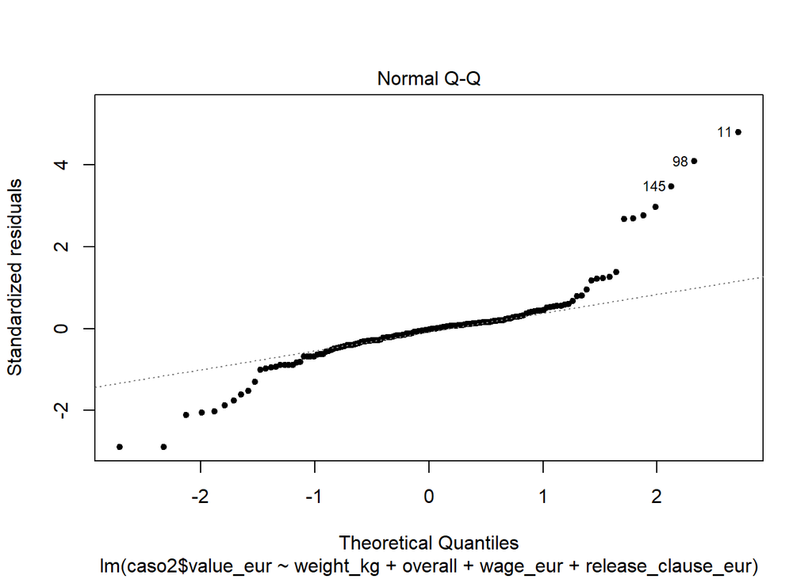

```r
plot(modeloBest,2,pch=20)
```

```r
shapiro.test(modeloBest$residuals)
```

```
##
##  Shapiro-Wilk normality test
##
## data:  modeloBest$residuals
## W = 0.83301, p-value = 8.72e-12
```

```r
lillie.test(modeloBest$residuals)
```

```
##
##  Lilliefors (Kolmogorov-Smirnov) normality test
##
## data:  modeloBest$residuals
## D = 0.1762, p-value = 2.356e-12
```

```r
ad.test(modeloBest$residuals)
```

```
##
##  Anderson-Darling normality test
##
## data:  modeloBest$residuals
## A = 7.6574, p-value < 2.2e-16
```

En este punto notamos que para todos los casos, el $p-value<0.05$, por tanto, se rechaza la hipótesis nula y esto comprueba que los residuos no provienen de una distribución normal.

### 3.3.5. Homocedasticidad.

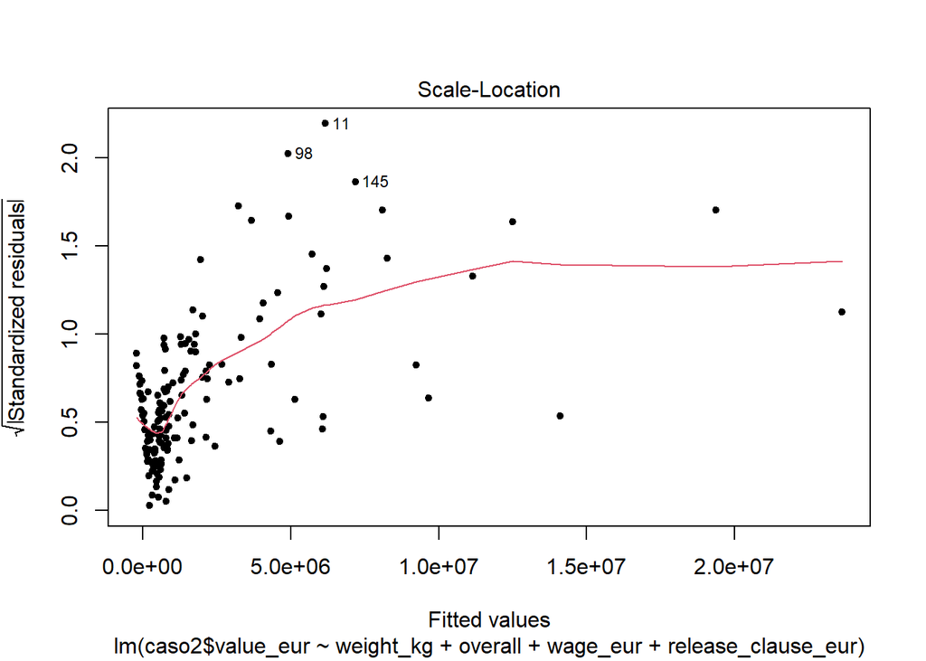

```r
plot(modeloBest,3, pch=20)
```

Estos valores deben estar distribuidos de manera aleatoria alrededor de cero sin ningún patrón. Para confirmar usamos el test de Breuch-Pagan.

```r
bptest(modeloBest)
```

```
##
##  studentized Breusch-Pagan test
##
## data:  modeloBest
## BP = 33.743, df = 4, p-value = 8.412e-07
```

Se rechaza la homocedasticidad de los residuos, ya que $p-value<0.05$.

### 3.3.6. No Multicolinealidad.

tener en cuenta que:

- Si $VIF=1$ ausencia total de colinealidad
- Si $1 < VIF < 5$ puede haber afectación, no en gran medida, de la colinealidad.
- Si $VIF>5$ se evidencia un índice alto de colinealidad

En este último caso, se debería examinar el modelo y excluir uno de los predictores que generen problema.

Para examinar la multicolinealidad, cargamos la librería *corrplot* y usamos la instrucción con el mismo nombre

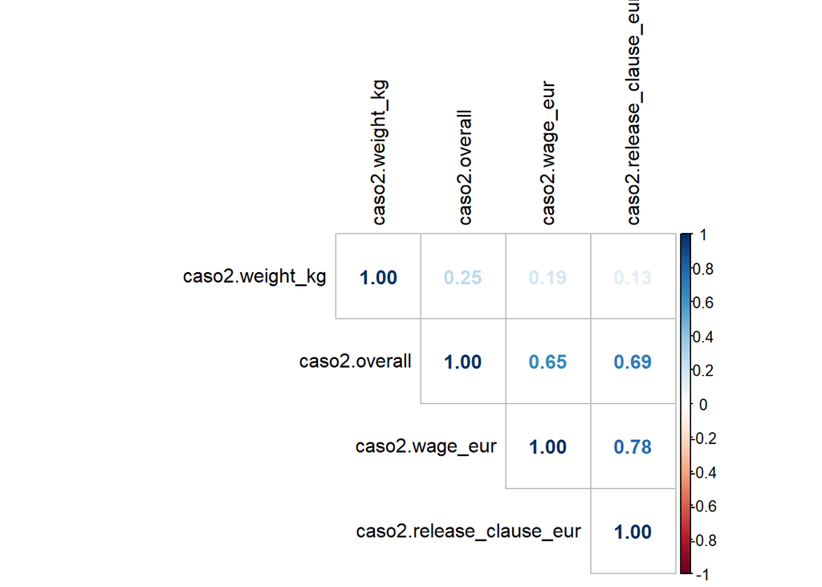

```r
corrplot(cor(data.frame(caso2$weight_kg,caso2$overall, caso2$wage_eur, caso2$release_clause_eur)), method = "number", tl.col = "black", type = "upper")
```

Ahora, calculamos la inflación de la varianza para determinar relaciones de una variable, ya no con otra individualmente, sino con varias. Para ello usamos la instrucción VIF del paquete car.

```r
data.frame(vif(modeloBest))
```

```
##                    vif.modeloBest.
## weight_kg                 1.080697
## overall                   2.114211
## wage_eur                  2.761563
## release_clause_eur        3.088492
```

Observemos, que no hay valores altos de VIF lo cual implica que no hay predictores que muestren una correlación lineal alta. Entonces se verifica la no multicolinealidad.

- Observamos que existe $1 < VIF < 5$ puede haber afectación, no en gran medida, de la colinealidad.

### 3.3.7. Independencia.

Podemos usar el test de Durbin-Watson y algún método gráfico de apoyo.

```r
dwtest(modeloBest)
```

```
##
##  Durbin-Watson test
##
## data:  modeloBest
## DW = 1.8181, p-value = 0.1312
## alternative hypothesis: true autocorrelation is greater than 0
```

como el $p-value>0.05$ entones no rechazamos la hipótesis nula de que los residuos son independientes.

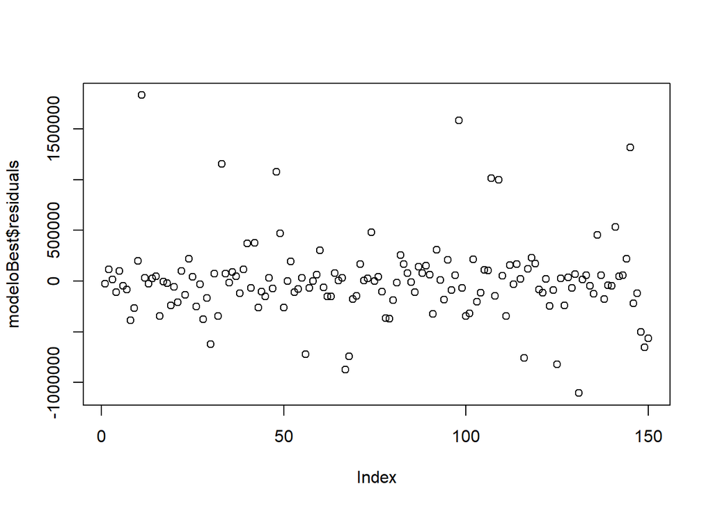

```r
plot(modeloBest$residuals)
```

no se observa ningún patrón en estos datos, además

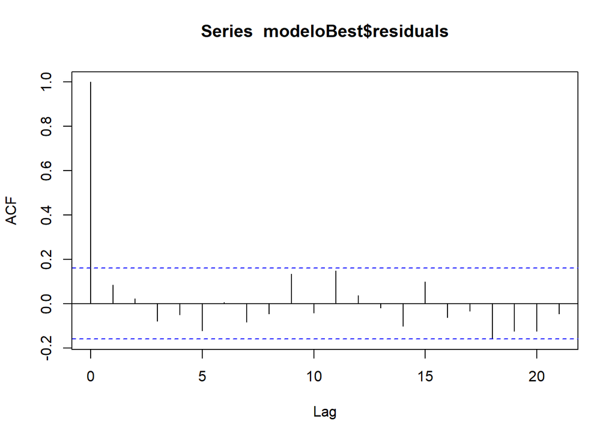

```r
acf(modeloBest$residuals)
```

los residuos evolución de manera adecuada ingresando a la región.

Finalmente,

### 3.3.8. Identificación de Valores Atípicos.

Podemos usar las siguientes gráficas,

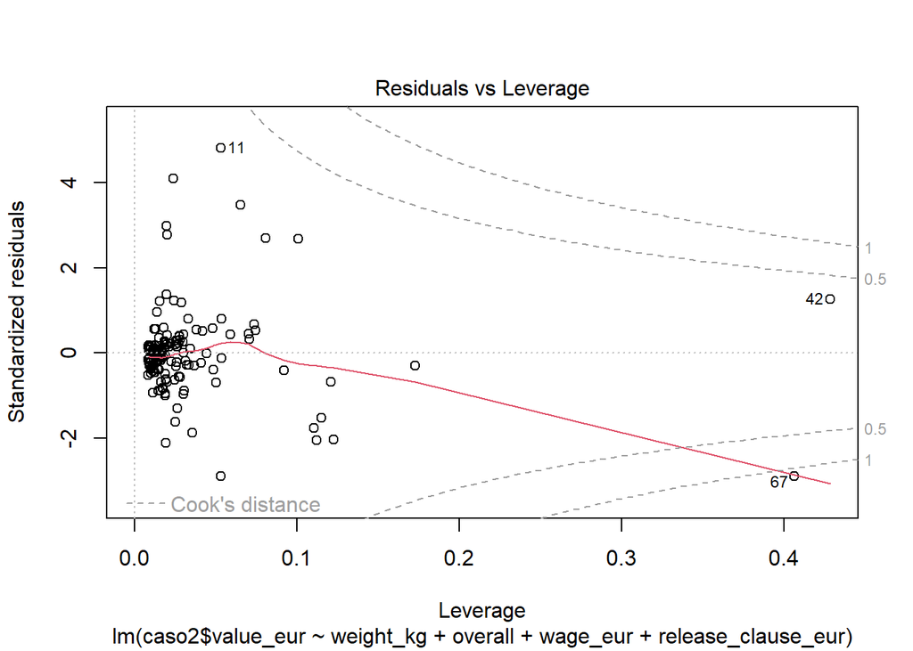

```r
plot(modeloBest,5)
```

Observamos que existe un dato atípico: **67**, vreificaremos más adelante si este es un valor influyente.

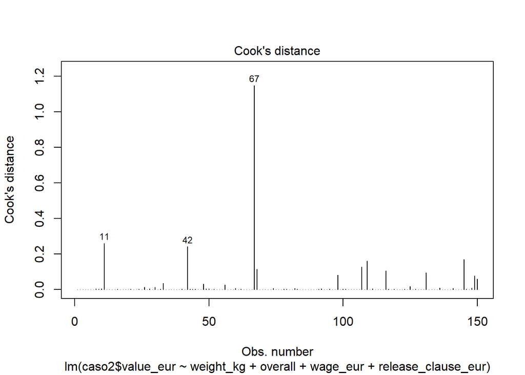

```r
plot(modeloBest,4)
```

Observamos que e valor atípico **67** sí es influyente porque supera la barrera de 1 en la distancia de Cook.

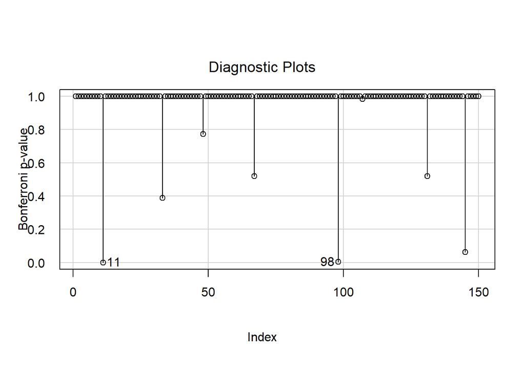

```r
influenceIndexPlot(modeloBest, vars="Bonf", las=1)
```

Nos muestra dos datos atípico, ver gráfico anterior, y un dato influyente, ver gráfico subsecuente.

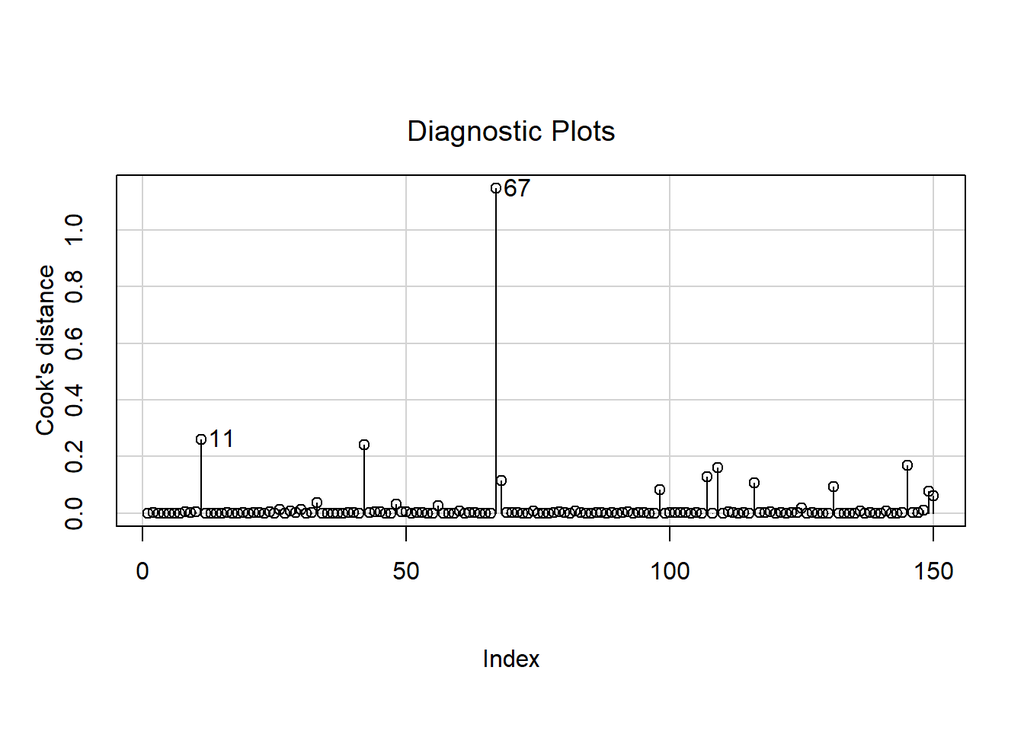

```r
influenceIndexPlot(modeloBest, vars="Cook")
```

La gráfica de puntos de influencia se hace mediante:

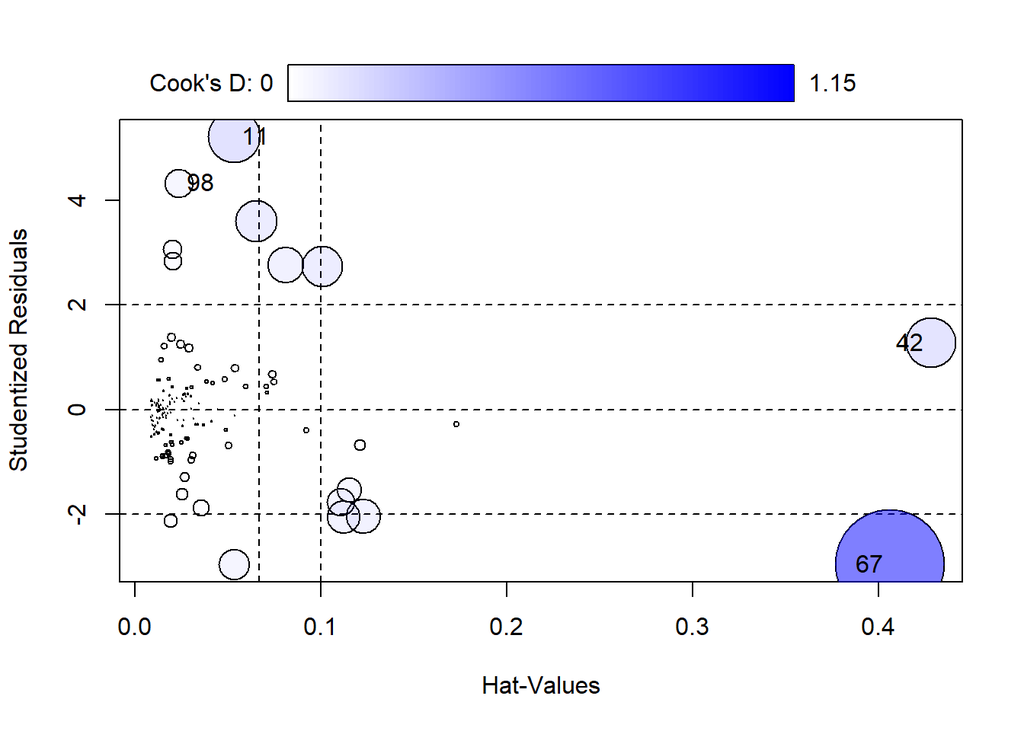

```
##      StudRes        Hat      CookD
## 11  5.226637 0.05332590 0.26048221
## 42  1.270978 0.42841061 0.24112537
## 67 -2.972544 0.40635932 1.14766597
## 98  4.332339 0.02370871 0.08120808
```

```r
influencePlot(modeloBest)
```

# Conclusiones, modelo regresión lineal múltiple.

Las variables de respuesta más significativas se hallaron mediante las direcciones *forward*, *backward* y *Stepwise-Mixta*, en todos los casos, las variables de respuesta más significativas fueron las siguientes: _release_clause_eur, *wage_eur*, *overall* y *weight_kg*.

A partir del mejor modelo generado a partir de estas variables, se realizó el análisis de los residuos para comprobar todas las hipótesis del modelo de regresión lineal múltiple.

En la linealidad, observamos que los datos están dispersos y no hay patrón, además de que la recta roja se comporta bastante bien (tiende a ser horizontal).

No obstante, al aplicar los test de shapiro y lillie (Kolmogorov-Smirnov) para todos los casos, el p−value<0.05, por tanto, se rechaza la hipótesis nula y hay indicio de que los residuos no provienen de una distribución normal.

Para la homocedasticidad, vemos que algunos valores no estan distribuidos de manera aleatoria alrededor de cero sin ningún patrón. Adicionalmente, usamos el test de Breuch-Pagan, el cual rechaza la homocedasticidad de los residuos.

En referencia a la independencia, usamos el test de Durbin-Watson y evidenciamos que el p-value es mayor que 0.05, lo cual significa que no rechazamos la hipótesis nula de que los residuos son independientes.

Por último, hallamos un valor atípico e influyente que traspasa la distancia de Cook.